# PubMed_LDA_5K

## Topic Modelling 3: Latent Dirichlet Allocation

### Before you begin

We will be using the gensim and nltk libraries in this notebook.  
Gensim does not work well with Python > 3.11, so create a separate virtual environment (venv) with Python 3.11 if you have a more recent Python version. You'll also need numpy, pandas and Jupyter notebook in this venv.

It is easiest to create and activate a venv with the above libraries in Anaconda Navigator, if you're using Anaconda. However, the default version in Anaconda of a gensim dependency, scipy, is version 1.15, which is not compatible with gensim. Using pip in a terminal, install scipy < 1.14 instead. For those of you who are comfortable setting up virtual environments, the requirements.txt file can be found at https://github.com/eukairos/topic-models.

Also note that some of the cells in this notebook may take some time to run, because some operations are computationally intensive.

```python
# ! pip install gensim, nltk
# nltk.download()
# uncomment the above if you need to install gensim and nltk. The nltk libraries take a while to download.
# you can monitor progress in the separate window nltk opens (look in your taskbar for a new icon that will appear), or go make a cup of coffee
```

### Steps in topic modelling

The steps involved are:-

1. Pre-process/normalize the data.
2. Create multi-word tokens (in our case, bigrams) to serve as data feedstock for the topic model.
3. Compile a dictionary from our bigrams.
4. Compile a corpus
5. Train our topic model from the corpus.
6. Visualize and evaluate our results

Let's go!

### Dataset

Download the csv file at this location: https://huggingface.co/datasets/owaiskha9654/PubMed_MultiLabel_Text_Classification_Dataset_MeSH into your current working directory. This dataset is released under academic free license - many thanks to Huggingface user owaiskha9564

```python
import pandas as pd
data = pd.read_csv('pubmed_abstracts.csv') # I renamed the file...
data.columns
```

```
Index(['Title', 'abstractText', 'meshMajor', 'pmid', 'meshid', 'meshroot', 'A',
       'B', 'C', 'D', 'E', 'F', 'G', 'H', 'I', 'J', 'L', 'M', 'N', 'Z'],
      dtype='str')
```

```python
# let's survey the dataset
data.head()
```

|  | Title | abstractText | meshMajor | pmid | meshid | meshroot | A | B | C | D | E | F | G | H | I | J | L | M | N | Z |
| --- | --- | --- | --- | --- | --- | --- | --- | --- | --- | --- | --- | --- | --- | --- | --- | --- | --- | --- | --- | --- |
| 0 | Expression of p53 and coexistence of HPV in pr... | Fifty-four paraffin embedded tissue sections f... | ['DNA Probes, HPV', 'DNA, Viral', 'Female', 'H... | 8549602 | [['D13.444.600.223.555', 'D27.505.259.750.600.... | ['Chemicals and Drugs [D]', 'Organisms [B]', '... | 0 | 1 | 1 | 1 | 1 | 0 | 0 | 1 | 0 | 0 | 0 | 0 | 0 | 0 |
| 1 | Vitamin D status in pregnant Indian women acro... | The present cross-sectional study was conducte... | ['Adult', 'Alkaline Phosphatase', 'Breast Feed... | 21736816 | [['M01.060.116'], ['D08.811.277.352.650.035'],... | ['Named Groups [M]', 'Chemicals and Drugs [D]'... | 0 | 1 | 1 | 1 | 1 | 1 | 1 | 0 | 1 | 1 | 0 | 1 | 1 | 1 |
| 2 | [Identification of a functionally important di... | The occurrence of individual amino acids and d... | ['Amino Acid Sequence', 'Analgesics, Opioid', ... | 19060934 | [['G02.111.570.060', 'L01.453.245.667.060'], [... | ['Phenomena and Processes [G]', 'Information S... | 1 | 1 | 0 | 1 | 1 | 0 | 1 | 0 | 0 | 0 | 1 | 0 | 0 | 0 |
| 3 | Multilayer capsules: a promising microencapsul... | In 1980, Lim and Sun introduced a microcapsule... | ['Acrylic Resins', 'Alginates', 'Animals', 'Bi... | 11426874 | [['D05.750.716.822.111', 'D25.720.716.822.111'... | ['Chemicals and Drugs [D]', 'Technology, Indus... | 1 | 1 | 1 | 1 | 1 | 0 | 1 | 0 | 0 | 1 | 0 | 0 | 0 | 0 |
| 4 | Nanohydrogel with N,N'-bis(acryloyl)cystine cr... | Substantially improved hydrogel particles base... | ['Antineoplastic Agents', 'Cell Proliferation'... | 28323099 | [['D27.505.954.248'], ['G04.161.750', 'G07.345... | ['Chemicals and Drugs [D]', 'Phenomena and Pro... | 1 | 1 | 0 | 1 | 1 | 0 | 1 | 0 | 0 | 1 | 0 | 0 | 0 | 0 |

the columns A - Z are one-hot encodings of class labels. We won't be making use of them for this notebook. You can remove them if you like. But they tell us that there are at least 14 topics in this dataset. The actual class labels are found in the meshroot column. The meshMajor terms could have been used as possible topics, but unfortunately there are about 11000 MESH terms here, which is too many for us to study.

```python
data['meshMajor'][0]
```

```
"['DNA Probes, HPV', 'DNA, Viral', 'Female', 'Humans', 'Immunohistochemistry', 'Papillomaviridae', 'Tumor Suppressor Protein p53', 'Uterine Cervical Dysplasia', 'Uterine Cervical Neoplasms']"
```

```python
# this cell extracts the classes from meshroot column, no need to run this

import ast
from itertools import chain

def extract_classes(series):
    def string_to_list(a_string):  # meshroot entries are strings, we convert them to lists first.
        raw = ast.literal_eval(f'[{a_string}]')
        # reference here: https://www.reddit.com/r/learnpython/comments/psjqrd/what_are_the_uses_of_the_ast_module_in_python/
        return raw
    return series.apply(string_to_list)

raw_topics = extract_classes(data['meshroot'])

topics = []

for n in range(1,100):  # this should be enough to catch all the meshroot classes
    raw_list = raw_topics[n]
    topics.extend(raw_list)

topics_list = list(set(chain.from_iterable(topics))) # flatten to a single list, then create a set of unique meshroot classes
sorted_topics_list = sorted(topics_list, key=lambda x: x[x.rfind('[')+1]) # sort by the character following an opening parenthesis
sorted_topics_list
```

```
['Anatomy [A]',
 'Organisms [B]',
 'Diseases [C]',
 'Chemicals and Drugs [D]',
 'Analytical, Diagnostic and Therapeutic Techniques, and Equipment [E]',
 'Psychiatry and Psychology [F]',
 'Phenomena and Processes [G]',
 'Disciplines and Occupations [H]',
 'Anthropology, Education, Sociology, and Social Phenomena [I]',
 'Technology, Industry, and Agriculture [J]',
 'Humanities [K]',
 'Information Science [L]',
 'Named Groups [M]',
 'Health Care [N]',
 'Geographicals [Z]']
```

```python
# dropping unwanted columns

to_drop = ['Title','pmid','meshMajor', 'meshid', 'A', 'B', 'C', 'D', 'E', 'F', 'G', 'H', 'I', 'J', 'L', 'M', 'N', 'Z']
data = data.drop(to_drop, axis=1)

# taking a sample
data = data.sample(n=5000, random_state=42)

# reseting the index
data = data.reset_index(drop=True)

# data
```

```python
# get a feel of the abstracts

def get_all_lengths(series):
    def get_abs_length(abstract):
        return(len(abstract))
    return series.apply(get_abs_length)

abstracts_length = get_all_lengths(data['abstractText'])

longest = max(abstracts_length)
shortest = min(abstracts_length)

print(longest, shortest)
```

```
3755 109
```

### Pre-processing/Normalization

```python
# First convert text to lowercase. Case is not required for our purposes.

data['abstractText'] = data['abstractText'].str.lower()
print(data['abstractText'][:3])
```

```
0    we reviewed the patterns of injuries sustained...
1    the effect of orthodontic-surgical treatment o...
2    sciatic nerves of 25-week-old genetically diab...
Name: abstractText, dtype: str
```

#### Stopwords

Stopwords are common words that typically do not carry significant meaning on their own and can be considered noise in the context of many NLP applications. Common stopwords are articles (a, an, the), prepositions (in, on, at, by), conjunctions (and, but), pronouns (i, you, we, he, she), verbs (is, are, was, were).  
Gensim provides a list of stopwords, and you can also customize stopwords like so:

```python
# Customise stopwords

import gensim
from gensim.parsing.preprocessing import STOPWORDS

# import a list of pubmed stopwords; put this file into your working directory.
pubstop = pd.read_csv('pubmed_stopwords.csv')
print(pubstop)
pubmed_stopwords = pubstop['stopwords'].to_list()

# create set of stopwords
custom_stopwords = set(STOPWORDS)
# add new stopwords
custom_stopwords.update(pubmed_stopwords)
# remove words from set (ie you want to keep the word)
# custom.stopwords.discard('not')
```

```
       stopwords
0     background
1   introduction
2      objective
3     objectives
4        purpose
..           ...
64             y
65             z
66       however
67            --
68        versus

[69 rows x 1 columns]
```

Since Pubmed is essentially a collection of studies, many abstracts will refer to themselves eg "in the present study", "this is a cross-sectional study". If we don't remove these, "studies" might turn up as a very prevalent topic. Similarly, many abstracts have headers such as 'background', 'objective', 'methods', 'results' and 'conclusion'. These are going to pop up very often. We can remove these as topic modelling is a vector space model that relies on a 'bag-of-words' approach. If I were using a language model for another NLP purpose, I might opt to retain the headers as they do provide some context information.

```python
# renove stopwords

def remove_stopwords(series):
    def clean_text(text):
        # split words
        words = text.split()
        # filter stopwords
        filtered = [word for word in words if word not in custom_stopwords]
        return ' '.join(filtered)
    return series.apply(clean_text)
```

```python
data['abstractText_no_stopwords'] = remove_stopwords(data['abstractText'])
data['abstractText_no_stopwords'][:5]
```

```
0    reviewed patterns injuries sustained 12 consec...
1    effect orthodontic-surgical submental-cervical...
2    sciatic nerves 25-week-old genetically diabeti...
3    effects temperature development raja microocel...
4    aim obtain mr images flexed-knee position comp...
Name: abstractText_no_stopwords, dtype: str
```

#### Remove numerals

Numbers are common in the results sections of abstracts, but they do not add meaningfully to topic discovery. We'll remove them.

```python
import re # this is the native Python regex module

def remove_numbers(series):
    def rem_no(text):
        pattern = r'\b\d+(\.\d{1,2})?\b'
        cleaned_text = re.sub(pattern, '', text)
        cleaned_text = cleaned_text.strip()
        return cleaned_text
    return series.apply(rem_no)
```

```python
data['abstractText_no_numbers'] = remove_numbers(data['abstractText_no_stopwords'])
```

#### Tokenization

Tokenization is a wide topic, but here we'll only look at word tokenization. For topic modelling purposes, it just means breaking down text into individual words, because all we want is just a collection of words in a collection of documents.

```python
# Next, tokenize the text into individual words

from nltk.tokenize import word_tokenize

def tokenize_series(text_series: pd.Series) -> pd.Series:
    tokenize = lambda text: word_tokenize(text)
    return text_series.apply(tokenize)
```

```python
data['abstract_tokens'] = tokenize_series(data['abstractText_no_numbers'])
```

```python
data['abstract_tokens'][5:10]
```

```
5    [develop, rapid, calf-side, test, determine, s...
6    [systemic, sclerosis, (, ssc, ), presents, sti...
7    [competitive, polymerase, chain, reaction, qua...
8    [coordinating, care, terminally, ill, children...
9    [background, :, sleep-disordered, breathing, (...
Name: abstract_tokens, dtype: object
```

```python
# remove punctuation

import string

def no_punct(series):
    def remove_punct(word_list):
        return [word for word in word_list if word not in string.punctuation]
    return series.apply(remove_punct)
```

```python
data['abstract_no_punct'] = no_punct(data['abstract_tokens'])
```

```python
data.head()
```

|  | abstractText | meshroot | abstractText_no_stopwords | abstractText_no_numbers | abstract_tokens | abstract_no_punct |
| --- | --- | --- | --- | --- | --- | --- |
| 0 | we reviewed the patterns of injuries sustained... | ['Health Care [N]', 'Named Groups [M]', 'Organ... | reviewed patterns injuries sustained 12 consec... | reviewed patterns injuries sustained consecut... | [reviewed, patterns, injuries, sustained, cons... | [reviewed, patterns, injuries, sustained, cons... |
| 1 | the effect of orthodontic-surgical treatment o... | ['Named Groups [M]', 'Anatomy [A]', 'Analytica... | effect orthodontic-surgical submental-cervical... | effect orthodontic-surgical submental-cervical... | [effect, orthodontic-surgical, submental-cervi... | [effect, orthodontic-surgical, submental-cervi... |
| 2 | sciatic nerves of 25-week-old genetically diab... | ['Organisms [B]', 'Chemicals and Drugs [D]', '... | sciatic nerves 25-week-old genetically diabeti... | sciatic nerves -week-old genetically diabetic ... | [sciatic, nerves, -week-old, genetically, diab... | [sciatic, nerves, -week-old, genetically, diab... |
| 3 | effects of temperature on development of raja ... | ['Phenomena and Processes [G]', 'Analytical, D... | effects temperature development raja microocel... | effects temperature development raja microocel... | [effects, temperature, development, raja, micr... | [effects, temperature, development, raja, micr... |
| 4 | the aim of this study was to obtain mr images ... | ['Named Groups [M]', 'Analytical, Diagnostic a... | aim obtain mr images flexed-knee position comp... | aim obtain mr images flexed-knee position comp... | [aim, obtain, mr, images, flexed-knee, positio... | [aim, obtain, mr, images, flexed-knee, positio... |

As you can see, the abstract_tokens column does not hold strings, it holds lists of words. We'll need to handle subsequent processing as lists, instead of strings. Punctuation does not remove hyphens linking words eg "high-dose".

#### Stemming and Lemmatization

Stemming involves reducing a word to its base or root form by removing prefixes, suffixes or other word endings. For example, the stem of 'running' and 'ran' would be 'run'.  
Lemmatization is rather more sophisticated than stemming: it considers the context and meaning of the word. For example, the lemma of 'running' is 'run', but the lemma of 'lovely' is not necessarily 'love' but it could be - the context matters. The lemma of 'better' and 'best' would be 'good', wouldn't it?  
Lemmatization is more accurate than stemming, but is also more computationally intensive and thus slower.

Both stemming and lemmatization serve to improve accuracy of downstream NLP by reducing words to their base forms. You usually select one or the other, depending on your use case. For use cases where speed is more important than accuracy, you might opt to do stemming instead of lemmatization, otherwise lemmatization is usually preferred.

In the cell below, we use nltk's lemmatizer which leverages WordNet, and is widely considered to be one of the more accurate lemmatizers.

WordNet (https://wordnet.princeton.edu/) is a large lexical database that groups words into sets of synonyms (called synsets) and records semantic relationships between these words. It is a valuable open-source resource for various NLP tasks. In the example below, WordNet helps more accurate lemmatization by identifying the part-of-speech which a word resides in.

```python
# lemmatize

import nltk
from nltk.stem import WordNetLemmatizer
from nltk.corpus import wordnet

def lemmatize_words(series: pd.Series) -> pd.Series:
    """
    Lemmatizes words in a pandas Series where each element is a list of words, using NLTK.
    Improves lemmatization by using POS (Part-of-Speech) tagging.
    """
    def get_wordnet_pos(word):
        """
        Maps a word's Penn Treebank POS tag to a WordNet POS tag. (Penn Treebank POS is nltk's internal word tagging)
        This is needed for accurate lemmatization with NLTK.
        """
        tag = nltk.pos_tag([word])[0][1][0].upper()
        tag_dict = {"J": wordnet.ADJ,
                    "N": wordnet.NOUN,
                    "V": wordnet.VERB,
                    "R": wordnet.ADV}
        return tag_dict.get(tag, wordnet.NOUN)  # Default to NOUN if no match

    def lemmatize_list(word_list):
        """Lemmatizes a single list of words using NLTK and POS tagging."""
        lemmatizer = WordNetLemmatizer()
        return [lemmatizer.lemmatize(word, get_wordnet_pos(word)) for word in word_list]

    return series.apply(lemmatize_list)
```

The following cell will take a while, lemmatization is computationally intensive. It took about 20min on my PC. YMML.

```python
data['lemmas'] = lemmatize_words(data['abstract_no_punct'])
data['lemmas'][5:10]
```

```
5    [develop, rapid, calf-side, test, determine, s...
6    [systemic, sclerosis, ssc, present, stiffness,...
7    [competitive, polymerase, chain, reaction, qua...
8    [coordinate, care, terminally, ill, child, dif...
9    [background, sleep-disordered, breathing, sdb,...
Name: lemmas, dtype: object
```

If you compare the ['lemmas'] column to the ['abstract_tokens'] column, you can see that, for example, 'coordinating' was lemmatized to 'coordinate' but 'breathing' was not lemmatized.

#### Preprocessing/normalization summary

Collectively, converting to lower case, removing stopwords and punctuation, tokenization, stemming and lemmatization (and some other preprocessing steps that we did not cover here, such as handling special characters and accents) serve to render various text data from different sources into a standard format to ensure consistency and reduce variability. We refer to this as "**normalization**" of text data. Note that this meaning is different from what you may have learnt about normalization in database courses (like 1st normal form, 2nd normal form) and in statistics (min-max scaling, z-score standardization etc...). The stem is the same, but the lemma is not; again - the context matters.

#### Try yourself

Using just native Python modules (try using string and unicode), write functions to:

1. remove special characters, and
2. remove accents.

#### N-Grams

N-grams refer to contiguous items in a given text. They are used in a wide variety of NLP tasks, including topic modelling. If the items are word tokens, unigrams are single words, bigrams are 2 words. So 'quick' is a unigram, 'quick brown' and 'brown fox' are bigrams. Triplets of consecutive items are trigrams. From the same text, you'll usually generate overlapping n-grams to feed into the topic model. The higher the 'n', the more information can be derived, at higher computational cost. For example 'machine learning' has a different meaning from 'machine' and 'learning'. Typically, libraries will generate overlapping n-grams like 'quick brown' and 'brown fox' in order to capture semantic meanings more fully. But it doesn't necessarily hold that the higher n you use, the more accurate the results of your modelling.

So, what is the ideal 'n'? It depends on your text. For short texts like the abstracts we're reading here, unigrams might well suffice. But then again, medical jargon is full of multi-grams (think 'Type IV renal tubular acidosis' or 'percutaneous endoscopic gastrostomy tube placement'). For our exploration purposes in this notebook, we'll work with unigrams and bigrams.

```python
# compute bigrams

from gensim.models import Phrases # the Phrases method automatically detects common phrases

# function to make bigrams
def compute_bigram(series, min_count, threshold):
    bigram_model = Phrases(series.to_list(), min_count = min_count, threshold = threshold)
    # to_list() converts the pandas column to a list, because Phrases works with lists.

    # to make trigrams, just repeat the function! similarly for quadrigrams, pentagrams etc....
    # trigram_model = Phrases(bigram_model, min_count=min_count, threshold=threshold)

    def apply_phrases(unigram_list):
        return bigram_model[unigram_list]

    return series.apply(apply_phrases)
```

```python
min_count = 5
threshold = 10

data['bigrams'] = compute_bigram(data['lemmas'], min_count=min_count, threshold = threshold)
```

```python
data['bigrams'][50:80]
```

```
50    [trial_conduct, effect, feed, mixture, ammoniu...
51    [numerous, hallux, proximal, phalanx, osteotom...
52    [transcriptional, epigenetic, regulation, fund...
53    [objective_evaluate, factor_associate, frequen...
54    [new, specie, rhinolophus, philippinensis, chi...
55    [described, multiple, benign, chondromatous, i...
56    [histological_examination, nissl, golgi, stain...
57    [article, author, consider, opportunity, learn...
58    [production, purification, detoxification, cho...
59    [structure, chemical, nature, serologically, d...
60    [osteopontin, osteoblast-secreted, protein, as...
61    [compound, ly253963, ,-thiadiazol, --, ylcyana...
62    [cytoskeletal, actin, regulate, part, rho, rho...
63    [understand, control, mechanism_underlie, gast...
64    [establish, expression, full-length, hiv-, tra...
```

[output cut: 16 more lines]

Bigrams are linked with underscores. You can see that we now have 'trial_conduct' and 'factor_associate' in the text. Bigrams add further semantic richness to the dataset.

We can also inspect the tokens.

```python
sample = list(data['bigrams'][1])
sample
```

```
['effect',
 'orthodontic-surgical',
 'submental-cervical',
 'region',
 'evaluate',
 'limited_number',
 'study',
 'aim_evaluate',
 'submental-cervical',
 'soft_tissue',
 'contour',
 'change',
 'follow',
 'mandibular',
 'advancement',
 'set-back',
 'procedure',
 'bilateral',
 'sagittal',
 'split',
 'ramus',
 'osteotomy',
 'sixty-seven',
 'include_study',
 'consist',
 'skeletal',
 'class_ii',
 'underwent',
 'mandibular',
 'advancement',
 'surgery',
 'consist',
 'skeletal',
 'class_iii',
 'underwent',
 'mandibular',
 'set-back',
 'surgery',
 'linear',
 'angular',
```

[output cut: 68 more lines]

```
 'length',
 'soft_tissue',
 'follow',
 'mandibular',
 'set-back',
 'ratio',
 'c-point',
 'projection',
 'soft_tissue',
 'pogonion',
 '·',
 'c-point',
 'soft_tissue',
 'menton',
 'distance']
```

### Build the dictionary and training corpus

```python
# Adapted from https://www.machinelearningplus.com/nlp/topic-modeling-gensim-python/
# and https://radimrehurek.com/gensim/auto_examples/tutorials/run_lda.html

from gensim.corpora import Dictionary

# Create a dictionary representation of the documents
id2word = Dictionary(data['bigrams'])

# filter out rare words and extremely common words
id2word.filter_extremes(no_below = 5, no_above = 0.95)
```

We might want to remove rare words and extremely common words (ie they behave like stopwords) like we would remove outliers when cleaning structured data. 'Rare' and 'common' in this context means across documents, not within documents. The hyperparameter 'no_below' and 'no_above' means that we want to remove words occuring in less than 5 documents and in more than 95% of documents. Again, these are not learnable by the model, you'll have to adjust these. Depending on your use case and the size of your dataset, you might not want to filter rare, common, or both. If your dataset is small, for example, you would prefer to keep as many tokens as possible available for training. If you're trying to identify instances of a rare disease in a large corpus (one that doesn't get coded into structured data, which is why you're using topic modelling in the first place), you would not want to filter 'no_below'.

```python
# create corpus

texts = data['bigrams']

corpus = [id2word.doc2bow(text) for text in texts]

print(corpus[:1])
```

```
[[(0, 1), (1, 1), (2, 1), (3, 1), (4, 1), (5, 1), (6, 2), (7, 1), (8, 2), (9, 1), (10, 4), (11, 1), (12, 1), (13, 2), (14, 1), (15, 2), (16, 1), (17, 3), (18, 1), (19, 5), (20, 1), (21, 1), (22, 1), (23, 1), (24, 1), (25, 1), (26, 1), (27, 1), (28, 1), (29, 1), (30, 1), (31, 1), (32, 1), (33, 1), (3…
```

Under the hood, gensim creates a unique id for each word in each document. The result is a Dictionary object. The id is the first number in each tuple in the sample above - you can see it's a running number.

Using the dictionary as input, the 'doctobow' method then counts the occurrences of each token - this is the second number in each tuple above. This representation, known as a 'bag-of-words', is used by our topic model.

```python
# to see which id maps to which word:
id2word[10]
```

```
'fracture'
```

```python
# this is a more readable view
[[(id2word[id], freq) for id, freq in cp] for cp in corpus[:1]]
```

```
[[('bladder', 1),
  ('chronic', 1),
  ('common', 1),
  ('consecutive', 1),
  ('die', 1),
  ('disability', 1),
  ('fall', 2),
  ('fell', 1),
  ('foot', 2),
  ('force', 1),
  ('fracture', 4),
  ('frequent', 1),
  ('great', 1),
  ('height', 2),
  ('hematoma', 1),
  ('impact', 2),
  ('important', 1),
  ('include', 3),
  ('initial', 1),
  ('injury', 5),
  ('internal', 1),
  ('jump', 1),
  ('low_extremity', 1),
  ('morbidity', 1),
  ('neurologic', 1),
  ('organ', 1),
  ('patient', 1),
  ('pattern', 1),
  ('pelvic', 1),
  ('possible', 1),
  ('primary', 1),
  ('prolong', 1),
  ('range', 1),
  ('recognize', 1),
  ('renal', 1),
  ('renal_artery', 1),
  ('result', 2),
  ('review', 1),
  ('rib', 1),
  ('risk', 1),
  ('secondary', 1),
  ('significant', 1),
  ('skeletal', 2),
  ('spinal', 1),
  ('stabilization', 1),
  ('survival', 1),
  ('survive', 1),
  ('sustain', 2),
  ('tract', 1),
  ('transection', 1),
  ('upper_extremity', 1),
  ('vertical', 1)]]
```

```python
# Let's see how many tokens and documents we have

print('Number of unique tokens: %d' % len(id2word))
print('Number of documents: %d' % len(corpus))
```

```
Number of unique tokens: 9592
Number of documents: 5000
```

### Training our Topic Model

We will use Latent Dirichlet Allocation. This may take quite a while.

```python
# LDA model
# the API reference here: https://radimrehurek.com/gensim/models/ldamodel.html

import gensim
import logging

# turning on logging enables us to monitor training progress. We want to see that training eventually converges.
for handler in logging.root.handlers[:]:
    logging.root.removeHandler(handler)
logging.basicConfig(format='%(asctime)s : %(levelname)s : %(message)s', level=logging.NOTSET)
```

```python
num_topics = 14  # because the dataset owner had 14 classes for his abstracts.
chunksize = 1000
passes = 10
iterations = 20
update_every = 1
eval_every = 5
random_state = 42

lda_model = gensim.models.ldamodel.LdaModel(
    corpus = corpus,
    id2word = id2word,
    num_topics = num_topics,
    random_state = random_state,
    update_every = update_every,
    eval_every = eval_every,
    chunksize = chunksize,
    passes = passes,
    alpha = 'auto',
    eta = 'auto',
    per_word_topics=True)
```

[output not shown]

[output cut: 599 more lines]

There's a lot to unpack in the parameters and hyperparameters. You can read the documentation in the link provided for what these do. For now, note that we chose arbitrarily k = 14, and set alpha and beta to 'auto' (gensim refers to beta as eta, I have no idea why). 'Auto' means that the hyperparameters are automatically tuned during training. Gensim doesn't explain how, but it is probably by Bayesian optimization.  
While the dataset owner has pre-identified 14 topics for us here, that's usually not going to be the case for your future projects. You'll have to make a judgment on how many topics is optimum. This will often depend on your appreciation of the dataset and the domain knowledge of your domain experts.

```python
# let's have a look at the topics discovered:
import pprint
pprint.pp(lda_model.print_topics(num_topics, num_words=10))
#doc_lda = lda_model[corpus]
```

```
2026-02-10 09:50:27,208 : INFO : topic #0 (0.126): 0.018*"image" + 0.009*"area" + 0.009*"volume" + 0.008*"compare" + 0.007*"lesion" + 0.007*"time" + 0.006*"small" + 0.006*"technique" + 0.006*"perform" + 0.006*"brain"
2026-02-10 09:50:27,210 : INFO : topic #1 (0.163): 0.010*"case" + 0.009*"surgery" + 0.009*"patient" + 0.008*"year" + 0.007*"present" + 0.007*"injury" + 0.007*"pain" + 0.006*"procedure" + 0.006*"mean" + 0.006*"diabetes"
2026-02-10 09:50:27,214 : INFO : topic #2 (0.154): 0.014*"patient" + 0.014*"case" + 0.012*"tumor" + 0.008*"diagnosis" + 0.008*"month" + 0.008*"clinical" + 0.008*"survival" + 0.008*"cancer" + 0.007*"treat" + 0.007*"therapy"
2026-02-10 09:50:27,218 : INFO : topic #3 (0.202): 0.007*"health" + 0.007*"child" + 0.007*"use" + 0.006*"risk" + 0.006*"care" + 0.006*"increase" + 0.005*"age" + 0.005*"measure" + 0.005*"score" + 0.005*"woman"
2026-02-10 09:50:27,221 : INFO : topic #4 (0.196): 0.022*"protein" + 0.016*"gene" + 0.013*"expression" + 0.007*"receptor" + 0.007*"activity" + 0.007*"role" + 0.006*"suggest" + 0.006*"binding" + 0.006*"region" + 0.006*"function"
2026-02-10 09:50:27,224 : INFO : topic #5 (0.214): 0.014*"model" + 0.008*"provide" + 0.007*"''" + 0.007*"``" + 0.007*"approach" + 0.006*"analysis" + 0.006*"information" + 0.006*"present" + 0.006*"base" + 0.006*"identify"
2026-02-10 09:50:27,227 : INFO : topic #6 (0.132): 0.016*"sequence" + 0.015*"specie" + 0.011*"dna" + 0.011*"gene" + 0.008*"isolates" + 0.008*"variant" + 0.008*"mutation" + 0.007*"--" + 0.007*"form" + 0.007*"compound"
2026-02-10 09:50:27,229 : INFO : topic #7 (0.102): 0.010*"block" + 0.007*"heart" + 0.006*"observe" + 0.006*"platelet" + 0.006*"pd" + 0.006*"vascular" + 0.006*"aneurysm" + 0.006*"damage" + 0.006*"effect" + 0.005*"inflammation"
2026-02-10 09:50:27,230 : INFO : topic #8 (0.201): 0.045*"cell" + 0.012*"increase" + 0.011*"activity" + 0.010*"mouse" + 0.010*"effect" + 0.009*"human" + 0.007*"expression" + 0.007*"inhibit" + 0.006*"inhibition" + 0.006*"induced"
2026-02-10 09:50:27,232 : INFO : topic #9 (0.121): 0.015*"infection" + 0.014*"sample" + 0.013*"strain" + 0.011*"detect" + 0.011*"antibody" + 0.011*"positive" + 0.010*"test" + 0.009*"virus" + 0.008*"assay" + 0.008*"bacteria"
2026-02-10 09:50:27,234 : INFO : topic #10 (0.170): 0.022*"increase" + 0.021*"effect" + 0.018*"level" + 0.015*"day" + 0.015*"decrease" + 0.013*"change" + 0.012*"rat" + 0.012*"control" + 0.011*"concentration" + 0.009*"week"
2026-02-10 09:50:27,235 : INFO : topic #11 (0.108): 0.014*"response" + 0.012*"il-" + 0.008*"vaccine" + 0.008*"ra" + 0.007*"effect" + 0.007*"m" + 0.007*"level" + 0.006*"infection" + 0.006*"skin" + 0.006*"virus"
2026-02-10 09:50:27,236 : INFO : topic #12 (0.157): 0.008*"high" + 0.008*"surface" + 0.007*"concentration" + 0.007*"different" + 0.006*"temperature" + 0.006*"structure" + 0.006*"reaction" + 0.006*"water" + 0.005*"solution" + 0.005*"range"
2026-02-10 09:50:27,237 : INFO : topic #13 (0.134): 0.033*"p" + 0.024*"group" + 0.014*"compare" + 0.010*"n" + 0.009*"high" + 0.009*"low" + 0.009*"vs." + 0.009*"serum" + 0.008*"control" + 0.008*"level"
```

```
[(0,
  '0.018*"image" + 0.009*"area" + 0.009*"volume" + 0.008*"compare" + '
  '0.007*"lesion" + 0.007*"time" + 0.006*"small" + 0.006*"technique" + '
  '0.006*"perform" + 0.006*"brain"'),
 (1,
  '0.010*"case" + 0.009*"surgery" + 0.009*"patient" + 0.008*"year" + '
  '0.007*"present" + 0.007*"injury" + 0.007*"pain" + 0.006*"procedure" + '
  '0.006*"mean" + 0.006*"diabetes"'),
 (2,
  '0.014*"patient" + 0.014*"case" + 0.012*"tumor" + 0.008*"diagnosis" + '
  '0.008*"month" + 0.008*"clinical" + 0.008*"survival" + 0.008*"cancer" + '
  '0.007*"treat" + 0.007*"therapy"'),
 (3,
  '0.007*"health" + 0.007*"child" + 0.007*"use" + 0.006*"risk" + 0.006*"care" '
  '+ 0.006*"increase" + 0.005*"age" + 0.005*"measure" + 0.005*"score" + '
  '0.005*"woman"'),
 (4,
  '0.022*"protein" + 0.016*"gene" + 0.013*"expression" + 0.007*"receptor" + '
  '0.007*"activity" + 0.007*"role" + 0.006*"suggest" + 0.006*"binding" + '
  '0.006*"region" + 0.006*"function"'),
 (5,
  '0.014*"model" + 0.008*"provide" + 0.007*"\'\'" + 0.007*"``" + '
  '0.007*"approach" + 0.006*"analysis" + 0.006*"information" + 0.006*"present" '
  '+ 0.006*"base" + 0.006*"identify"'),
 (6,
  '0.016*"sequence" + 0.015*"specie" + 0.011*"dna" + 0.011*"gene" + '
  '0.008*"isolates" + 0.008*"variant" + 0.008*"mutation" + 0.007*"--" + '
  '0.007*"form" + 0.007*"compound"'),
 (7,
  '0.010*"block" + 0.007*"heart" + 0.006*"observe" + 0.006*"platelet" + '
  '0.006*"pd" + 0.006*"vascular" + 0.006*"aneurysm" + 0.006*"damage" + '
  '0.006*"effect" + 0.005*"inflammation"'),
 (8,
  '0.045*"cell" + 0.012*"increase" + 0.011*"activity" + 0.010*"mouse" + '
  '0.010*"effect" + 0.009*"human" + 0.007*"expression" + 0.007*"inhibit" + '
  '0.006*"inhibition" + 0.006*"induced"'),
 (9,
  '0.015*"infection" + 0.014*"sample" + 0.013*"strain" + 0.011*"detect" + '
  '0.011*"antibody" + 0.011*"positive" + 0.010*"test" + 0.009*"virus" + '
  '0.008*"assay" + 0.008*"bacteria"'),
 (10,
  '0.022*"increase" + 0.021*"effect" + 0.018*"level" + 0.015*"day" + '
  '0.015*"decrease" + 0.013*"change" + 0.012*"rat" + 0.012*"control" + '
  '0.011*"concentration" + 0.009*"week"'),
 (11,
  '0.014*"response" + 0.012*"il-" + 0.008*"vaccine" + 0.008*"ra" + '
  '0.007*"effect" + 0.007*"m" + 0.007*"level" + 0.006*"infection" + '
  '0.006*"skin" + 0.006*"virus"'),
 (12,
  '0.008*"high" + 0.008*"surface" + 0.007*"concentration" + 0.007*"different" '
  '+ 0.006*"temperature" + 0.006*"structure" + 0.006*"reaction" + '
  '0.006*"water" + 0.005*"solution" + 0.005*"range"'),
 (13,
  '0.033*"p" + 0.024*"group" + 0.014*"compare" + 0.010*"n" + 0.009*"high" + '
  '0.009*"low" + 0.009*"vs." + 0.009*"serum" + 0.008*"control" + '
  '0.008*"level"')]
```

We asked the model to print out the top 10 words contributing to each topic.The numbers preceding each word are weights that indicate the contribution of that word to the topic discovered, similar to the coefficients in regression.

Just by eyeballing my output (yours will differ), I can make out, for instance that topic 1 is about some surgical procedure in diabetics, topic 2 is about cancer and topic 4 is about gene studies. The rest are not so perceivable to me.

### Visualization

Let's visualize the model using pyLDAvis. This package works only for models built with LDA, and it has an integration module with gensim, making it easy for us to create the visualization.

```python
# Adapted from https://www.machinelearningplus.com/nlp/topic-modeling-gensim-python/

# !pip install pyLDAvis - uncomment if not installed yet

import pyLDAvis
import pyLDAvis.gensim

pyLDAvis.enable_notebook()
vis = pyLDAvis.gensim.prepare(lda_model, corpus, id2word)
vis
```

```
2026-02-10 09:50:36,180 : DEBUG : performing inference on a chunk of 5000 documents
2026-02-10 09:50:38,091 : DEBUG : 4812/5000 documents converged within 50 iterations
```

[interactive chart not shown]

Move your cursor around the visualization to explore it. Note that the topic numbering here starts from 1 instead of zero, and do not correspond to the native ones from gensim. They are sorted by size of bubble. Each bubble is one topic: the larger the bubble, the more prevalent the topic. Quoting the machinelearningplus.com website: "a good topic model will have fairly big, non-overlapping bubbles scattered throughout the chart."

We can also look at the topic distribution for each abstract.

```python
for i, doc_bow in enumerate(corpus[:3]):
    topic_distribution = lda_model[doc_bow]
    print(f'\nAbstract{i+1} : {topic_distribution}')
```

```
Abstract1 : ([(1, np.float32(0.79968596)), (2, np.float32(0.05748044)), (5, np.float32(0.069096275)), (7, np.float32(0.040130038)), (12, np.float32(0.013642671))], [(0, [1]), (1, [1, 7, 2]), (2, [1, 5, 2]), (3, [1, 2]), (4, [1, 2]), (5, [1]), (6, [1]), (7, [1]), (8, [1]), (9, [12, 5, 1]), (10, [1]),…

Abstract2 : ([(0, np.float32(0.1645523)), (1, np.float32(0.103903316)), (2, np.float32(0.19829024)), (5, np.float32(0.047604173)), (7, np.float32(0.015186191)), (9, np.float32(0.031628963)), (10, np.float32(0.1417362)), (12, np.float32(0.031299636)), (13, np.float32(0.25675657))], [(42, [7, 10]), (5…

Abstract3 : ([(1, np.float32(0.21788669)), (4, np.float32(0.2287588)), (7, np.float32(0.020831233)), (8, np.float32(0.2932238)), (10, np.float32(0.21878701))], [(36, [8, 4, 1, 10, 7]), (62, [10, 8, 1, 4]), (70, [10, 8, 4, 1]), (82, [10, 1]), (86, [1]), (90, [10, 8, 1]), (99, [10, 8, 4, 1, 7]), (103,…
```

```python
# Just get the topics alone:
for i, doc_bow in enumerate(corpus[:3]):
    topic_distribution = lda_model.get_document_topics(doc_bow, minimum_probability=0.01)

    print(f'\nAbstract {i+1}:')
    for topic_id, prob in topic_distribution:
        print(f'  Topic {topic_id}: {prob*100:.2f}%')
```

```
Abstract 1:
  Topic 1: 79.97%
  Topic 2: 5.75%
  Topic 5: 6.91%
  Topic 7: 4.01%
  Topic 12: 1.37%

Abstract 2:
  Topic 0: 16.46%
  Topic 1: 10.39%
  Topic 2: 19.83%
  Topic 5: 4.76%
  Topic 7: 1.52%
  Topic 9: 3.16%
  Topic 10: 14.17%
  Topic 12: 3.13%
  Topic 13: 25.68%

Abstract 3:
  Topic 1: 21.79%
  Topic 4: 22.88%
  Topic 7: 2.08%
  Topic 8: 29.33%
  Topic 10: 21.88%
```

```python
# for reference, here are the abstracts:
for i in [0,1,2]:
    print(data.iloc[i]['abstractText'])
    print('\n')
    print('-'*50)
```

```
we reviewed the patterns of injuries sustained by 12 consecutive fallers and jumpers in whom primary impact was onto the feet. the fall heights ranged from 20 to 100 ft. the 12 patients sustained 49 significant injuries. skeletal injuries were most frequent and included 15 lower extremity fractures,…


--------------------------------------------------
the effect of orthodontic-surgical treatment on submental-cervical region was evaluated in a very limited number of studies. the aim of this study was to evaluate submental-cervical soft tissue contour changes following mandibular advancement and set-back procedures via bilateral sagittal split ramu…


--------------------------------------------------
sciatic nerves of 25-week-old genetically diabetic (c57bl/ks [db/db]) mice and their litter-mate controls were removed, and their metabolic incorporation of [3h]fucose and [14c]leucine into myelin was studied in vitro. untreated diabetic animals showed significant increases (p less than 0.05) in the…


--------------------------------------------------
```

### Evaluation

#### Coherence

The main metric for measuring a topic model's performance is coherence. Coherence measures how interpretable and semantically meaningful the topics discovered by the model are to humans, by assessing the degree to which the high-scoring words within a discovered topic are related to each other. Coherence is derived through a pipeline of 4 steps: segmentation, probability estimation, confirmation measure and aggregation.

1. Segmentation - the top N words for a given topic are segmented into sets, according to the metric's segmentation strategy (eg all pairwise combinations of the top N words).
2. Probability estimation - the co-occurrence probabilities between word segments are calculated based on a reference corpus (which can be the corpus itself or an external reference corpus). The calculation method varies according to metric eg co-occurrence in documents.
3. Confirmation measure - this measures how much the co-occurrence or relatedness of words support the idea that they belong to the same topic. Again this is specific to metric used eg logarithmic conditional probabilities.
4. Aggregation - individual confirmation scores for all word segments are then aggregated to produce a single coherence score for that topic, typically by averaging or summing. The overall coherence of the model is averaged to produce an overall coherence.

These are some information blogs on topic coherence:

1. https://towardsdatascience.com/understanding-topic-coherence-measures-4aa41339634c/
2. https://towardsdatascience.com/c%E1%B5%A5-topic-coherence-explained-fc70e2a85227/
3. https://www.baeldung.com/cs/topic-modeling-coherence-score

In the cell below, we'll use the UMass metric. This metric has several advantages for our purpose: (1) it is less computationally demanding, and (2) it uses the corpus itself as a reference whereas other metrices require an external reference. We'll try out different numbers of topics. You can experiment further with different metrics, such as c_v and c_uci.

### Perplexity

Perplexity in text processing is a measure of next word prediction in a document. If a model is good at predicting the next word, it is less 'perplexed'. So a model that has read many PubMed abstracts is probably confident of seeing 'patient', 'diagnosis' and 'treatment' appearing together. But it will be more perplexed if 'pickle ball' suddenly appears in the document. Here's the equation for perplexity in language modeling:

[figure not shown]

Perplexity computation in LDA is a bit more involved than perplexity in general; in computing perplexity for LDA, we are working with two probability distributions, so the equation is:

[figure not shown]

This simply means we are trying to infer topic distributions on unseen documents using the learned topic-word distributions, and then calculating the likelihood (perplexity is the exponentiation of the negative log-likelihood) of observing the test words given the inferred topics.

A perfect model has a perplexity of 1, it is never unsure. A model with a perplexity of 10 has difficulty selecting among 10 candidate words for next-word prediction. A model with a perplexity of 10000 is essentially choosing words at random, since our corpus' vocabulary is only 9592 tokens.

Perplexity has to be calculated by testing on an unseen hold-out set. In gensim, this can be done using the 'bound' method. The bound method essentially uses a subsample of words within each document for inference, and evaluates on the remaining words. You can also explicitly split the corpus into training set and a test set, and separately compute perplexity on the test set.

```python
# adapted from https://www.machinelearningplus.com/nlp/topic-modeling-gensim-python/
# train a few models and get their corresponding coherence scores using a GridSearch-like approach

import gensim
from gensim.models.ldamodel import LdaModel
from gensim.models.coherencemodel import CoherenceModel
from gensim.models.callbacks import ConvergenceMetric, PerplexityMetric, CoherenceMetric

# Create callback
perplexity_logger = PerplexityMetric(corpus=corpus, logger='shell')
convergence_logger = ConvergenceMetric(logger='shell')
coherence_logger = CoherenceMetric(corpus=corpus, coherence='u_mass', logger='shell')

# import logging
# logging.basicConfig(format='%(asctime)s : %(levelname)s : %(message)s', level=logging.INFO)

def compute_coherence_values(dictionary, corpus, texts, limit, start, step):
    coherence_values = []
    model_list = []
    perplexity_info = []

    for num_topics in range(start, limit, step):
        # Create callback
        perplexity_logger = PerplexityMetric(corpus=corpus, logger='shell')
        convergence_logger = ConvergenceMetric(logger='shell')
        coherence_logger = CoherenceMetric(corpus=corpus, coherence='u_mass', logger='shell')

        model = LdaModel(
            corpus = corpus,
            id2word = id2word,
            num_topics = num_topics,
            chunksize = chunksize,
            passes = passes,
            eval_every = 5,
            iterations = iterations,
            alpha = 'auto',
            eta = 'auto',
            random_state=42,
            callbacks= [perplexity_logger, coherence_logger, convergence_logger],
            per_word_topics = True)

        # check convergence via perplexity
        perplexity = model.log_perplexity(corpus)
        bound = model.bound(corpus)

        model_list.append(model)
        perplexity_info.append({'num_topics': num_topics, 'perplexity': perplexity, 'bound': bound})
        coherencemodel = CoherenceModel(model=model, texts=texts, dictionary=dictionary, coherence='u_mass')
        coherence_values.append(coherencemodel.get_coherence())

    return model_list, coherence_values, perplexity_info
```

So actually I have tried between 2 to 100 topics, and the best coherence and perplexity scores are between 2 to 5. So to make your life easier, we'll just run 2 to 6 topics.

```python
# this may take hours!

logging.getLogger('gensim').setLevel(logging.WARNING) # to turn off logging

start = 2
limit = 7
step = 1

chunksize = 2000
passes = 20
iterations = 100

model_list, coherence_values, perplexity_info = compute_coherence_values(dictionary=id2word, corpus=corpus, texts=texts, limit=limit, start=start, step=step)
```

```
2026-02-10 09:51:37,868 : WARNING : updated prior is not positive
2026-02-10 09:57:34,013 : WARNING : updated prior is not positive
```

```python
# let's have a look at the scores
print(coherence_values)
print('\n')
print(perplexity_info)
```

```
[np.float64(-1.873552222689118), np.float64(-2.019509439814596), np.float64(-1.9690333329653176), np.float64(-2.1067035475270837), np.float64(-2.2032096176658507)]


[{'num_topics': 2, 'perplexity': np.float64(-8.104665547843778), 'bound': np.float64(-3347745.544671342)}, {'num_topics': 3, 'perplexity': np.float64(-8.071500827371814), 'bound': np.float64(-3334045.9937751144)}, {'num_topics': 4, 'perplexity': np.float64(-8.035201752306874), 'bound': np.float64(-3…
```

```python
# Get the model with highest (least negative) coherence
optimal_idx = coherence_values.index(max(coherence_values))
optimal_model = model_list[optimal_idx]
max_dict = max(perplexity_info, key = lambda x: x['perplexity'])
optimal_perplexity_idx = perplexity_info.index(max_dict)

print(f"Optimal topics: {start + optimal_idx * step}")
print(f"Best coherence: {coherence_values[optimal_idx]}")
print(f"Lowest perplexity: {perplexity_info[optimal_perplexity_idx]['perplexity']}")
```

```
Optimal topics: 2
Best coherence: -1.873552222689118
Lowest perplexity: -8.034567732097852
```

[output not shown]

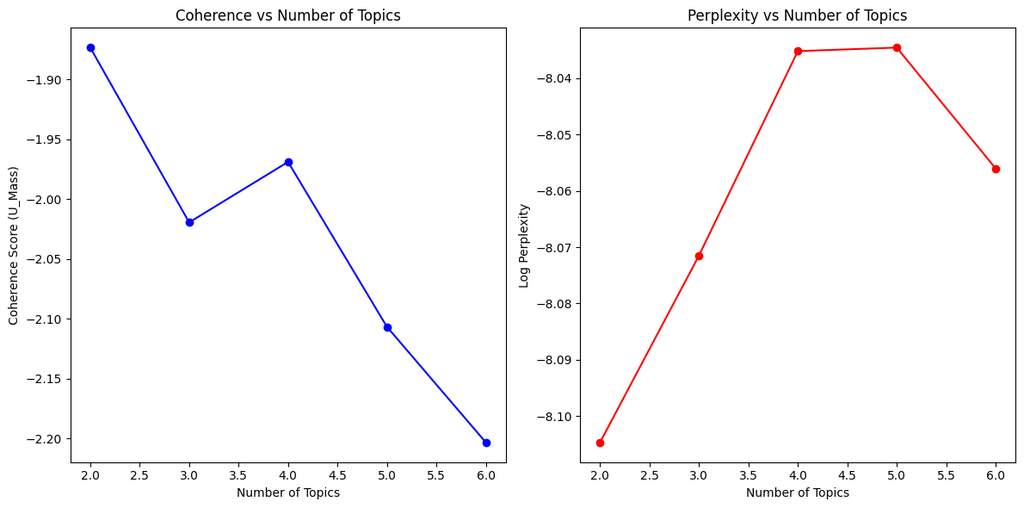

```python
# plot the graph, and look for the elbow

import matplotlib.pyplot as plt
logging.getLogger('matplotlib').setLevel(logging.WARNING) # turn off logging for matplotlib too

#x = range(start, limit, step)
#plt.plot(x, coherence_values)
#plt.xlabel('Number of Topics')
#plt.ylabel('Coherence Score')
#plt.show()

plt.figure(figsize=(12, 6))

plt.subplot(1, 2, 1)
plt.plot(range(start, limit, step), coherence_values, 'b-o')
plt.xlabel('Number of Topics')
plt.ylabel('Coherence Score (U_Mass)')
plt.title('Coherence vs Number of Topics')

plt.subplot(1, 2, 2)
perplexities = [info['perplexity'] for info in perplexity_info]
plt.plot(range(start, limit, step), perplexities, 'r-o')
plt.xlabel('Number of Topics')
plt.ylabel('Log Perplexity')
plt.title('Perplexity vs Number of Topics')
plt.tight_layout()
plt.show()
```

The 'elbow' where the increase/decrease starts leveling off is usually taken as the sweet spot for determining the number of topics to assign. For UMass, the metric is always negative, because it is based on the logarithm of a fraction. The closer the fraction is to one, the better the coherence. So the closer UMass is to zero (since log(1) = 0), the better the coherence.  
In our case, there isn't any elbow at all, it just seems to get worse with more topics! So we look at perplexity as well. Note that the y-axis for perplexity here is the log-perplexity, which is what gensim reports. If you want the actuals, just exponentiate it. Since a perfect perplexity is 1, the perfect log(perplexity)=0, so, like UMass, the closer the number is to zero, the better the performance. (Gensim reports log perplexity for readability).  
The best combination of coherence and perplexity seems to be at 4 topics, let's re-run the model with 4 topics, and see whether the topics uncovered make sense.

```python
num_topics = 4
chunksize = 2000
passes = 10
iterations = 20
update_every = 1
eval_every = 5
random_state = 42

lda_model = gensim.models.ldamodel.LdaModel(
    corpus = corpus,
    id2word = id2word,
    num_topics = num_topics,
    random_state = random_state,
    update_every = update_every,
    eval_every = eval_every,
    chunksize = chunksize,
    passes = passes,
    alpha = 'auto',
    eta = 'auto',
    per_word_topics=True)
```

For further reading on how to estimate the number of topics, this blog is quite useful: https://www.meganstodel.com/posts/callbacks/

```python
pyLDAvis.enable_notebook()
vis2 = pyLDAvis.gensim.prepare(lda_model, corpus, id2word)
vis2
```

[interactive chart not shown]

### Recap

In this notebook, we learnt the following:

1. Text preprocessing and normalization.
2. Text augmentation by creating n-grams.
3. Compiling a corpus and dictionary for training.
4. Training a gensim LDA model and monitoring for training convergence.
5. Visualizing the model, and
6. Evaluating the model using coherence and perplexity.

Having done all that, it seems rather strange for a dataset of 5000 abstracts to contain only four topics. In our next notebook, we'll use a language model to perform topic modelling on this dataset, and we can compare the 2 methods.